# Exploring Household Appliance Usage Patterns

## 👀Overview of the Data

### This data set records the usage of household appliances in four time periods that are more in line with my own living conditions. It includes the total time the device is used, the type of device used, and the time when the usage is recorded. I want to use this data to understand which time period of the day I spend more time at home, so that I can understand my living conditions and infer whether I go to bed early and go to class during the day, as well as the electricity usage to verify the electricity bill I pay for rent every time.

[figure not shown]

A picture of home appliances

## ⏲️Total Electricity Consumption by Time Period

### It can be seen that the afternoon and evening are the periods when electricity consumption is the highest, because I stay at home the longest during these two periods. There are fewer classes in the afternoon and classes may end late in the morning, so I stay at home in the afternoon, and use electrical appliances at night when cooking. Midnight is the shortest period because I sleep most of the time, so I only use electrical appliances when I stay up late.

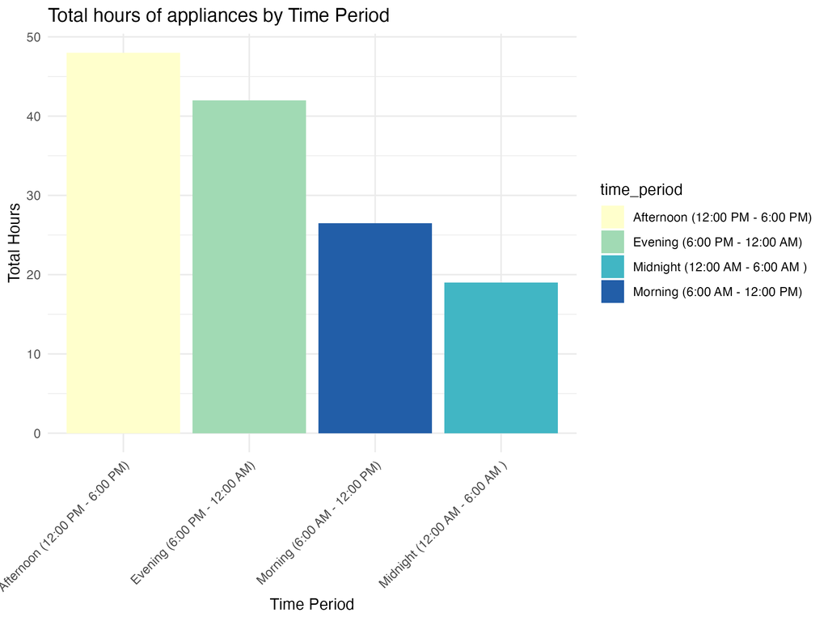

Bar chart showing total hours of appliances use by time period. Afternoon and Evening have the highest usage.